# NOAA Storm Data Preparation Analysis

Parker Oakes

February 23, 2019

## Synopsis

This report is to submit an analysis to a hypothetical government or municipal manager who would be responsible in preparing for severe weather events and will need to prioritize resources for different types of events. Albeit, there are no specific recommendations in this report, the analysis of the U.S. National Oceanic and Atmospheric Administration’s (NOAA) storm database is sufficient with the following two questions:

1. Across the United States, which types of events are most harmful with respect to population health?
2. Across the United States, which types of events have the greatest economic consequences?

The data and meta data supporting this analysis is located in the following locations:

- [NOAA Storms Data Base](https://d396qusza40orc.cloudfront.net/repdata%2Fdata%2FStormData.csv.bz)
- [National Weather Service Storm Documentation](https://d396qusza40orc.cloudfront.net/repdata%2Fpeer2_doc%2Fpd01016005curr.pdf)
- [National Climatic Data Center Storm Events FAQ](https://d396qusza40orc.cloudfront.net/repdata%2Fpeer2_doc%2FNCDC%20Storm%20Events-FAQ%20Page.pdf)

## Data Processing

### Loading the data from NOAA and R Libraries

```r
library(ggplot2)
library(reshape2)
setwd("/home/alanoakes/Documents/Programming Notes/DataScience/Mod5 - Repoducible Research/NoaaStormData")
url<-"https://d396qusza40orc.cloudfront.net/repdata%2Fdata%2FStormData.csv.bz2"
download.file(url=url,destfile="repdata_data_StormData.csv.bz2")
NOAA.Data<-read.csv("repdata_data_StormData.csv.bz2")
list("Dimensions of Data Set"=dim(NOAA.Data),
     "% NA's in Data Set"=mean(is.na(NOAA.Data)),
     "Total Count of NA's of Data Set"=sum(is.na(NOAA.Data)),
     "Variable Names"=names(NOAA.Data))
```

```
## $`Dimensions of Data Set`
## [1] 902297     37
##
## $`% NA's in Data Set`
## [1] 0.05229737
##
## $`Total Count of NA's of Data Set`
## [1] 1745947
##
## $`Variable Names`
##  [1] "STATE__"    "BGN_DATE"   "BGN_TIME"   "TIME_ZONE"  "COUNTY"
##  [6] "COUNTYNAME" "STATE"      "EVTYPE"     "BGN_RANGE"  "BGN_AZI"
## [11] "BGN_LOCATI" "END_DATE"   "END_TIME"   "COUNTY_END" "COUNTYENDN"
## [16] "END_RANGE"  "END_AZI"    "END_LOCATI" "LENGTH"     "WIDTH"
## [21] "F"          "MAG"        "FATALITIES" "INJURIES"   "PROPDMG"
## [26] "PROPDMGEXP" "CROPDMG"    "CROPDMGEXP" "WFO"        "STATEOFFIC"
## [31] "ZONENAMES"  "LATITUDE"   "LONGITUDE"  "LATITUDE_E" "LONGITUDE_"
## [36] "REMARKS"    "REFNUM"
```

As we can see with this data set provided by NOAA it has a decent amount of rows and columns. It has a total of 1,745,947 misssing data points throughout the data set making up 5.23% of the data provided. There are 37 columns (“variables”) to our data. This amount of variables gives us many things we could include in our total analysis. However, for our analysis we will need to focus on the variables supporting our analysis on population health and economic consquences. Before we are able to make any real measurements to our two questions we must determine a sample of most frequent and consequential storm types to evaluate in the variable “EVTYPE”.

### Creating a Sampling of the NOAA Data

Next, I will build a top-ten list of the most frequent and consequential storm types to appriately size our data for the initial two questions.

```r
TopTen<-table(NOAA.Data$EVTYPE)
TopTenD<-as.data.frame(TopTen)
TopTenL<-head(TopTenD[order(-TopTenD$Freq),],10)
EventTypes<-TopTenL$Var1
EventTypes<-as.character(EventTypes)
NOAA.Data$EVTYPE<-as.character(NOAA.Data$EVTYPE)
head(TopTenD[order(-TopTenD$Freq),],10)
```

```
##                   Var1   Freq
## 244               HAIL 288661
## 856          TSTM WIND 219940
## 760  THUNDERSTORM WIND  82563
## 834            TORNADO  60652
## 153        FLASH FLOOD  54277
## 170              FLOOD  25326
## 786 THUNDERSTORM WINDS  20843
## 359          HIGH WIND  20212
## 464          LIGHTNING  15754
## 310         HEAVY SNOW  15708
```

As we can see with our above top-ten list, the frequency of occurences for these storm types is rather large. I notice in our top-ten items that wind has been notated four seperate times (e.g. *“TSTM WIND”,“THUNDERSTORM WIND”,“THUNDERSTORM WINDS”,“HIGH WIND”*). There is no absolute notation from the NWS to clarify these four wind categories, but suffice it to say this has been a vary frequent occurence in the United States.

### Pre-Processing Our Data for Resulting Analysis

Next we will pre-process our data with these top-ten storm types to perform our two question national impact analysis.

```r
# Question 1
Question1<-NOAA.Data[NOAA.Data$EVTYPE==EventTypes,c(8,23,24)]
names(Question1)<-c("EventType","Fatalities","Injuries")
Question1$EventType<-as.factor(Question1$EventType)
Question1$Fatalities<-as.numeric(Question1$Fatalities)
Question1$Injuries<-as.numeric(Question1$Injuries)
Q1Melt<-melt(Question1,na.rm=T)
# Question 2
Question2<-NOAA.Data[NOAA.Data$EVTYPE==EventTypes,c(8,26,28)]
names(Question2)<-c("EventType","PropDamage","CropDamage")
Question2$EventType<-as.factor(Question2$EventType)
Question2$PropDamage<-as.numeric(Question2$PropDamage)
Question2$CropDamage<-as.numeric(Question2$CropDamage)
Q2Melt<-melt(Question2,na.rm=T)
# Summaries of Both Datasets
list("Question 1 Data Set"=summary(Q1Melt),
     "Question 2 Data Set"=summary(Q2Melt))
```

```
## $`Question 1 Data Set`
##              EventType           variable         value
##  HAIL             :57446   Fatalities:80517   Min.   :   0.0000
##  TSTM WIND        :44456   Injuries  :80517   1st Qu.:   0.0000
##  THUNDERSTORM WIND:16618                      Median :   0.0000
##  TORNADO          :12172                      Mean   :   0.0947
##  FLASH FLOOD      :10820                      3rd Qu.:   0.0000
##  FLOOD            : 5092                      Max.   :1228.0000
##  (Other)          :14430
##
## $`Question 2 Data Set`
##              EventType           variable         value
##  HAIL             :57446   PropDamage:80517   Min.   : 1.00
##  TSTM WIND        :44456   CropDamage:80517   1st Qu.: 1.00
##  THUNDERSTORM WIND:16618                      Median : 1.00
##  TORNADO          :12172                      Mean   : 5.73
##  FLASH FLOOD      :10820                      3rd Qu.: 7.00
##  FLOOD            : 5092                      Max.   :19.00
##  (Other)          :14430
```

## Results

I put together two seperate stacked barplots to determine two variables for analysis:

1. Which “Event Type” has the cumulative impact on resources per NOAA’s data?
2. Which two health and economic variables are the most contributive to the “Event Type”?

### Question 1

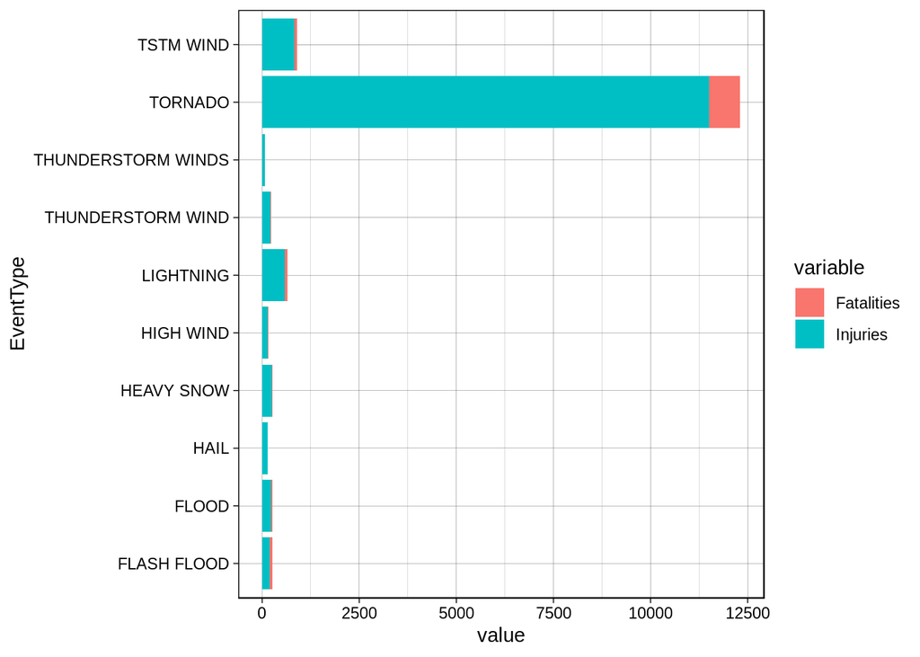

```r
# Plot
ggplot(data=Q1Melt,aes(x=EventType,y=value,fill=variable))+
  geom_bar(stat="identity")+coord_flip()+theme_linedraw()
```

```r
# Table
Q1<-as.data.frame(tapply(Q1Melt$value,Q1Melt$EventType,sum))
as.data.frame(Q1[order(-Q1),])
```

```
##                    Q1[order(-Q1), ]
## TORNADO                       12308
## TSTM WIND                       895
## LIGHTNING                       653
## FLASH FLOOD                     271
## FLOOD                           263
## HEAVY SNOW                      262
## THUNDERSTORM WIND               222
## HIGH WIND                       165
## HAIL                            141
## THUNDERSTORM WINDS               71
```

**Question 1:** Across the United States, which types of events are most harmful with respect to population health?

**Analysis 1:** Tornado frequencies of fatalities and injuries far out-weighed the other event types. Also, the four wind event types would easily come in second if they were combined together. Based off of our table which sums the fatalities and injuries per event type, we show nothing comes close to tornadoes with 12,308 counts of population health impacts. Our four wind event types equal a sum of 1,353 total injuries and fatalities.

### Question 2

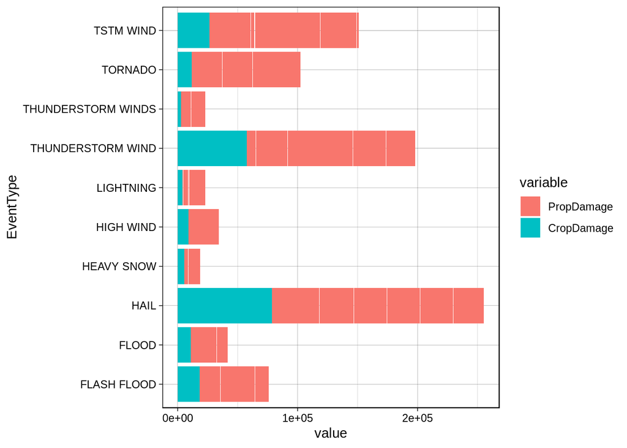

```r
# Plot
ggplot(data=Q2Melt,aes(x=EventType,y=value,fill=variable))+
  geom_bar(stat="identity",position="stack")+
  coord_flip()+theme_linedraw()
```

```r
# Table
Q2<-as.data.frame(tapply(Q2Melt$value,Q2Melt$EventType,sum))
as.data.frame(Q2[order(-Q2),])
```

```
##                    Q2[order(-Q2), ]
## HAIL                         255380
## THUNDERSTORM WIND            197902
## TSTM WIND                    150818
## TORNADO                      102388
## FLASH FLOOD                   75968
## FLOOD                         41609
## HIGH WIND                     34270
## LIGHTNING                     22878
## THUNDERSTORM WINDS            22843
## HEAVY SNOW                    18622
```

**Question 2:** Across the United States, which types of events have the greatest economic consequences?

```r
# compare to most expensive against most occuring
NOAA.Data$EVTYPE<-as.character(NOAA.Data$EVTYPE)
NOAA.Data$PROPDMGEXP<-as.numeric(NOAA.Data$PROPDMGEXP)
NOAA.Data$CROPDMGEXP<-as.numeric(NOAA.Data$CROPDMGEXP)
Expense<-NOAA.Data$PROPDMGEXP+NOAA.Data$CROPDMGE
ExpEvents<-cbind.data.frame(NOAA.Data$REFNUM,NOAA.Data$EVTYPE,NOAA.Data$PROPDMGEXP,NOAA.Data$CROPDMGEXP)
ExpEvents$Expense<-ExpEvents$`NOAA.Data$PROPDMGEXP`+ExpEvents$`NOAA.Data$CROPDMGEXP`
x1<-tapply(ExpEvents$Expense,ExpEvents$`NOAA.Data$EVTYPE`,sum)
x1.1<-as.data.frame(x1)
head(as.data.frame(x1.1[order(-x1),]),10)
```

```
##                    x1.1[order(-x1), ]
## HAIL                          2545662
## THUNDERSTORM WIND             1965426
## TSTM WIND                     1486346
## TORNADO                       1017324
## FLASH FLOOD                    769164
## FLOOD                          414429
## HIGH WIND                      336095
## THUNDERSTORM WINDS             235766
## LIGHTNING                      232770
## WINTER STORM                   183641
```